# **Anticipating Payroll Surprises: A Statistical Learning Framework**

The U.S. Employment Situation Report is one of the most important macroeconomic releases for financial markets.Treasury yields, equity markets, foreign exchange markets, and interest rate expectations often react sharply following the release of the Employment Situation Report. However, market reactions are driven less by the payroll number itself than by how that number compares to expectations.

This project investigates whether publicly available economic and financial market data contain predictive information about future payroll surprises. Using labor market indicators from the Bureau of Labor Statistics (BLS) and economic data from the Federal Reserve Economic Data (FRED) database, I construct a model-based estimate of expected payroll growth and identify periods in which actual payroll growth meaningfully exceeded or fell short of model-implied expectations.

The resulting surprise measures are then used to train binary and multinomial classification models to identify future upside and downside payroll surprises. The objective is not simply to forecast payroll growth, but to identify the economic conditions most associated with labor market outcomes that have the potential to move financial markets.

By focusing on surprises rather than payroll levels, the analysis mirrors the way macroeconomic information is incorporated into asset prices and evaluates whether statistical learning techniques can identify conditions associated with labor market outcomes.

```python
import pandas as pd
import numpy as np
import matplotlib.pyplot as plt
import os
from fredapi import Fred
import warnings
warnings.filterwarnings('ignore')
from dotenv import load_dotenv; load_dotenv("C:\git-repository\BLS_prediction_project\BLS_jobs_report_model\.env")
import requests
import xgboost as xgb
from pandas_datareader import data as pdr
from sklearn.model_selection import (TimeSeriesSplit, RandomizedSearchCV, train_test_split)
from sklearn.pipeline import Pipeline
from sklearn.preprocessing import StandardScaler
from sklearn.linear_model import RidgeCV
from sklearn.metrics import (
    roc_auc_score,
    roc_curve,
    precision_recall_curve,
    classification_report,
    mean_squared_error,
    r2_score,
    mean_absolute_error,
    ConfusionMatrixDisplay
)
```

## **FRED Data Calls**

I have selected the following variables from the St Louis Federal Reserve because they capture key dimensions of labor and financial market conditions, growth expectations, and consumer sentiments that I believe may be influential to labor market surprises.

Due to the limits of some of my JOLTS variables, I must limit my dataset to observations from 2000 - 2025, which is far from ideal for a macroeconomic time series.

- **PAYEMS** – Total Nonfarm Payroll Employment. Measures the total number of paid workers in the U.S. economy excluding farm employees, private household employees, and nonprofit workers. This serves as the primary target variable for the project.
- **UNRATE** – Civilian Unemployment Rate. Measures the percentage of the labor force that is unemployed and actively seeking work. Rising unemployment rates often signal weakening labor market conditions.
- **ICSA** – Initial Claims for Unemployment Insurance. Measures the number of new unemployment benefit claims filed each week. Initial claims are considered a leading indicator of labor market deterioration.
- **CCSA** – Continuing Claims for Unemployment Insurance. Measures the number of individuals continuing to receive unemployment benefits. Continuing claims provide insight into the persistence of unemployment and the ability of displaced workers to find new employment.
- **DGS2** – 2-Year Treasury Constant Maturity Yield. Represents market expectations for short-term interest rates and Federal Reserve policy. The 2-year yield is highly sensitive to changes in economic outlook and labor market expectations.
- **DGS10** – 10-Year Treasury Constant Maturity Yield. Represents longer-term growth and inflation expectations. Changes in the 10-year yield often reflect shifts in investor sentiment regarding the broader economic outlook.
- **T10Y2Y** – 10-Year Minus 2-Year Treasury Yield Spread. Measures the slope of the Treasury yield curve. Yield curve inversions have historically been associated with slowing economic growth and elevated recession risk.
- **UMCSENT** – University of Michigan Consumer Sentiment Index. Measures consumer confidence regarding current and future economic conditions. Consumer sentiment can provide insight into future spending, hiring, and overall economic activity.

```python
fred = Fred(api_key=os.getenv('fred'))

series = [
    "PAYEMS",
    "UNRATE",
    "ICSA",
    "CCSA",
    "DGS2",
    "DGS10",
    "T10Y2Y",
    "UMCSENT"
]

start = "2000-01-01"
end = "2025-01-01"

fred_data = {}

for s in series:
    for attempt in range(5):
        try:
            fred_data[s] = fred.get_series(
                s,
                observation_start=start,
                observation_end=end
            )
            time.sleep(5)
            break
        except Exception as e:
            time.sleep(20)

df = pd.concat(fred_data, axis=1)

fred_df = df.resample("M").mean()
fred_df = fred_df.ffill()

fred_df.head()
```

|  | PAYEMS | UNRATE | ICSA | CCSA | DGS2 | DGS10 | T10Y2Y | UMCSENT |
| --- | --- | --- | --- | --- | --- | --- | --- | --- |
| 2000-01-31 | 131011.0 | 4.0 | 288400.0 | 2109800.0 | 6.440000 | 6.661000 | 0.221000 | 112.0 |
| 2000-02-29 | 131120.0 | 4.1 | 293750.0 | 2147500.0 | 6.610500 | 6.519500 | -0.091000 | 111.3 |
| 2000-03-31 | 131604.0 | 4.0 | 274750.0 | 2079000.0 | 6.528261 | 6.256522 | -0.271739 | 107.1 |
| 2000-04-30 | 131884.0 | 3.8 | 271600.0 | 2015400.0 | 6.403684 | 5.990526 | -0.413158 | 109.2 |
| 2000-05-31 | 132105.0 | 4.0 | 282250.0 | 1989500.0 | 6.809545 | 6.440455 | -0.369091 | 110.7 |

```python
fred_df = fred_df.rename(
    columns={
        'PAYEMS': 'payrolls',
        'UNRATE': 'unemployment_rate',
        'ICSA': 'initial_claims',
        'CCSA': 'cont_claims',
        'DGS2': '2yr_yield',
        'DGS10': '10yr_yield',
        'T10Y2Y': '10yr_2yr_spread',
        'UMCSENT': 'sentiment'
        }).reset_index()
```

```python
fred_df.rename(columns={'index': 'DATE'}, inplace=True)
fred_df['month'] = fred_df['DATE'].dt.month
fred_df['year'] = fred_df['DATE'].dt.year

fred_df.head()
```

|  | DATE | payrolls | unemployment_rate | initial_claims | cont_claims | 2yr_yield | 10yr_yield | 10yr_2yr_spread | sentiment | month | year |
| --- | --- | --- | --- | --- | --- | --- | --- | --- | --- | --- | --- |
| 0 | 2000-01-31 | 131011.0 | 4.0 | 288400.0 | 2109800.0 | 6.440000 | 6.661000 | 0.221000 | 112.0 | 1 | 2000 |
| 1 | 2000-02-29 | 131120.0 | 4.1 | 293750.0 | 2147500.0 | 6.610500 | 6.519500 | -0.091000 | 111.3 | 2 | 2000 |
| 2 | 2000-03-31 | 131604.0 | 4.0 | 274750.0 | 2079000.0 | 6.528261 | 6.256522 | -0.271739 | 107.1 | 3 | 2000 |
| 3 | 2000-04-30 | 131884.0 | 3.8 | 271600.0 | 2015400.0 | 6.403684 | 5.990526 | -0.413158 | 109.2 | 4 | 2000 |
| 4 | 2000-05-31 | 132105.0 | 4.0 | 282250.0 | 1989500.0 | 6.809545 | 6.440455 | -0.369091 | 110.7 | 5 | 2000 |

## **BLS Data Calls**

The JOLTS variables were selected because they capture both labor demand and labor market turnover. Together, they provide insight into hiring activity, worker confidence, and labor market deterioration, all of which may contain predictive information regarding future payroll growth and employment report surprises.

- **Job Openings Rate (JTS000000000000000JOR)** – Measures the number of job openings as a percentage of total employment plus job openings. This serves as a measure of labor demand and reflects employers' willingness to hire additional workers. Rising job opening rates generally indicate a strong labor market.
- **Hires Rate (JTS000000000000000HIR)** – Measures the number of hires during the month as a percentage of employment. The hires rate provides insight into the pace at which firms are actively adding workers and expanding payrolls.
- **Quits Rate (JTS000000000000000QUR)** – Measures the number of voluntary separations as a percentage of employment. The quits rate is often viewed as a measure of worker confidence, as employees are generally more willing to leave their jobs when alternative employment opportunities are readily available.
- **Layoffs and Discharges Rate (JTS000000000000000LDR)** – Measures involuntary separations initiated by employers as a percentage of employment. Rising layoffs and discharges typically indicate weakening labor market conditions and can serve as an early signal of economic deterioration.

```python
import json
import prettytable
bls_key = os.getenv('BLS')
```

```python
BLS_ENDPOINT = "https://api.bls.gov/publicAPI/v2/timeseries/data/"

def fetch_bls_series(series, **kwargs):
    if len(series) < 1 or len(series) > 25:
        raise ValueError("Must pass in between 1 and 25 series ids")
    headers = {'Content-Type': 'application/json'}
    payload = {
        'seriesid': series,
        'registrationKey': bls_key,
    }
    payload.update(kwargs)
    payload = json.dumps(payload)
    response = requests.post(BLS_ENDPOINT, data=payload, headers=headers)
    response.raise_for_status()
    result = json.loads(response.text)
    if result['status'] != 'REQUEST_SUCCEEDED':
        raise Exception(result['message'][0])
    return result
```

```python
series = ['JTS000000000000000JOR', 'JTS000000000000000HIR', 'JTS000000000000000QUR', 'JTS000000000000000LDR']
start_year = 1999
end_year = 2026
json_data = fetch_bls_series(series, startyear=start_year, endyear=end_year)

try:
    dfs = []

    for series in json_data['Results']['series']:
        df_initial = pd.DataFrame(series)
        series_col = df_initial['seriesID'][0]

        for i in range(0, len(df_initial) - 1):
            df_row = pd.DataFrame(df_initial['data'][i])
            df_row['seriesID'] = series_col

            if 'code' not in str(df_row['footnotes']):
                df_row['footnotes'] = ''
            else:
                df_row['footnotes'] = str(df_row['footnotes']).split("'code': '", 1)[1][:1]

            dfs.append(df_row)

    df = pd.concat(dfs, ignore_index=True)

    df.to_csv('blsdata.csv', index=False)

except Exception as e:
    json_data['status'] == 'REQUEST_NOT_PROCESSED'
    print('BLS API has given the following Response:', json_data['status'])
    print('Reason:', json_data['message'])
    print('Error:', str(e))
```

```python
openings_01_09_df = (
    df[df['seriesID'] == 'JTS000000000000000JOR']
    .set_index('periodName')[['value', 'year']]
    .rename(columns={'value':'job openings rate'})
)

hires_01_09_df = (
    df[df['seriesID'] == 'JTS000000000000000HIR']
    .set_index('periodName')[['value']]
    .rename(columns={'value':'hires rate'})
)

quit_01_09_df = (
    df[df['seriesID'] == 'JTS000000000000000QUR']
    .set_index('periodName')[['value']]
    .rename(columns={'value':'quit rate'})
)

discharge_01_09_df = (
    df[df['seriesID'] == 'JTS000000000000000LDR']
    .set_index('periodName')[['value']]
    .rename(columns={'value':'discharge rate'})
)

bls_01_09_df = (
    openings_01_09_df
    .join(hires_01_09_df, how='outer')
    .join(quit_01_09_df, how='outer')
    .join(discharge_01_09_df, how='outer')
)

print(bls_01_09_df['year'].unique())
```

```
['2018' '2017' '2016' '2015' '2014' '2013' '2012' '2011' '2010' '2009'
 '2008' '2007' '2006' '2005' '2004' '2003' '2002' '2001']
```

```python
series = ['JTS000000000000000JOR', 'JTS000000000000000HIR', 'JTS000000000000000QUR', 'JTS000000000000000LDR']
start_year = 2019
end_year = 2026
json_data = fetch_bls_series(series, startyear=start_year, endyear=end_year)

try:
    dfs = []

    for series in json_data['Results']['series']:
        df_initial = pd.DataFrame(series)
        series_col = df_initial['seriesID'][0]

        for i in range(0, len(df_initial) - 1):
            df_row = pd.DataFrame(df_initial['data'][i])
            df_row['seriesID'] = series_col

            if 'code' not in str(df_row['footnotes']):
                df_row['footnotes'] = ''
            else:
                df_row['footnotes'] = str(df_row['footnotes']).split("'code': '", 1)[1][:1]

            dfs.append(df_row)

    df = pd.concat(dfs, ignore_index=True)

    df.to_csv('blsdata.csv', index=False)

except Exception as e:
    json_data['status'] == 'REQUEST_NOT_PROCESSED'
    print('BLS API has given the following Response:', json_data['status'])
    print('Reason:', json_data['message'])
    print('Error:', str(e))
```

```python
openings_19_26_df = (
    df[df['seriesID'] == 'JTS000000000000000JOR']
    .set_index('periodName')[['value', 'year']]
    .rename(columns={'value':'job openings rate'})
)

hires_19_26_df = (
    df[df['seriesID'] == 'JTS000000000000000HIR']
    .set_index('periodName')[['value']]
    .rename(columns={'value':'hires rate'})
)

quit_19_26_df = (
    df[df['seriesID'] == 'JTS000000000000000QUR']
    .set_index('periodName')[['value']]
    .rename(columns={'value':'quit rate'})
)

discharge_19_26_df = (
    df[df['seriesID'] == 'JTS000000000000000LDR']
    .set_index('periodName')[['value']]
    .rename(columns={'value':'discharge rate'})
)

bls_19_26_df = (
    openings_19_26_df
    .join(hires_19_26_df, how='outer')
    .join(quit_19_26_df, how='outer')
    .join(discharge_19_26_df, how='outer')
)
print(bls_19_26_df['year'].unique())
```

```
['2026' '2025' '2024' '2023' '2022' '2021' '2020' '2019']
```

```python
bls_df = pd.concat([bls_01_09_df, bls_19_26_df]).reset_index()

print(bls_df.dtypes)
bls_df.head()
```

```
periodName           object
job openings rate    object
year                 object
hires rate           object
quit rate            object
discharge rate       object
dtype: object
```

|  | periodName | job openings rate | year | hires rate | quit rate | discharge rate |
| --- | --- | --- | --- | --- | --- | --- |
| 0 | April | 4.4 | 2018 | 3.8 | 2.3 | 1.2 |
| 1 | April | 4.4 | 2018 | 3.8 | 2.3 | 1.2 |
| 2 | April | 4.4 | 2018 | 3.8 | 2.3 | 1.2 |
| 3 | April | 4.4 | 2018 | 3.8 | 2.3 | 1.3 |
| 4 | April | 4.4 | 2018 | 3.8 | 2.3 | 1.3 |

```python
bls_df['month_year'] = bls_df['periodName'] + ' ' + bls_df['year'].astype(str)

num_cols = [
    'job openings rate',
    'hires rate',
    'quit rate',
    'discharge rate'
    ]
bls_df[num_cols] = bls_df[num_cols].apply(
    pd.to_numeric,
    errors='coerce'
)
```

```python
bls_df = bls_df.groupby(
    'month_year'
    ).agg(
        job_opening_rate = ('job openings rate', 'mean'),
        hire_rate = ('hires rate', 'mean'),
        quit_rate = ('quit rate', 'mean'),
        discharge_rate = ('discharge rate', 'mean')
    ).reset_index()
print(bls_df.dtypes)
```

```
month_year           object
job_opening_rate    float64
hire_rate           float64
quit_rate           float64
discharge_rate      float64
dtype: object
```

```python
bls_df['month_year'] = pd.to_datetime(bls_df['month_year'])

bls_df['month'] = bls_df['month_year'].dt.month
bls_df['year'] = bls_df['month_year'].dt.year
```

```python
bls_df['month']
bls_df = bls_df.sort_values('month_year')#.reset_index()
```

```python
bls_df.head()
```

|  | month_year | job_opening_rate | hire_rate | quit_rate | discharge_rate | month | year |
| --- | --- | --- | --- | --- | --- | --- | --- |
| 102 | 2001-01-01 | 3.8 | 3.605556 | 1.894444 | 1.422222 | 1 | 2001 |
| 76 | 2001-02-01 | 3.7 | 3.600000 | 1.905556 | 1.388889 | 2 | 2001 |
| 177 | 2001-03-01 | 3.5 | 3.633333 | 1.894444 | 1.422222 | 3 | 2001 |
| 0 | 2001-04-01 | 3.4 | 3.600000 | 1.894444 | 1.405556 | 4 | 2001 |
| 203 | 2001-05-01 | 3.2 | 3.616667 | 1.877778 | 1.400000 | 5 | 2001 |

## **Combining FRED and BLS Datasets**

```python
master_df = pd.merge(
    fred_df,
    bls_df,
    on=['year', 'month'],
    how='inner'
)

master_df.head()
```

|  | DATE | payrolls | unemployment_rate | initial_claims | cont_claims | 2yr_yield | 10yr_yield | 10yr_2yr_spread | sentiment | month | year | month_year | job_opening_rate | hire_rate | quit_rate | discharge_rate |
| --- | --- | --- | --- | --- | --- | --- | --- | --- | --- | --- | --- | --- | --- | --- | --- | --- |
| 0 | 2001-01-31 | 132703.0 | 4.2 | 340000.0 | 2395750.0 | 4.760000 | 5.160952 | 0.400952 | 94.7 | 1 | 2001 | 2001-01-01 | 3.8 | 3.605556 | 1.894444 | 1.422222 |
| 1 | 2001-02-28 | 132788.0 | 4.2 | 371250.0 | 2486500.0 | 4.656842 | 5.098947 | 0.442105 | 90.6 | 2 | 2001 | 2001-02-01 | 3.7 | 3.600000 | 1.905556 | 1.388889 |
| 2 | 2001-03-31 | 132751.0 | 4.3 | 387200.0 | 2585400.0 | 4.342273 | 4.885455 | 0.543182 | 91.5 | 3 | 2001 | 2001-03-01 | 3.5 | 3.633333 | 1.894444 | 1.422222 |
| 3 | 2001-04-30 | 132458.0 | 4.4 | 396750.0 | 2697250.0 | 4.234000 | 5.141000 | 0.907000 | 88.4 | 4 | 2001 | 2001-04-01 | 3.4 | 3.600000 | 1.894444 | 1.405556 |
| 4 | 2001-05-31 | 132408.0 | 4.3 | 394500.0 | 2819250.0 | 4.260000 | 5.391364 | 1.131364 | 92.0 | 5 | 2001 | 2001-05-01 | 3.2 | 3.616667 | 1.877778 | 1.400000 |

## **Feature Engineering**

### Engineered FRED Features

Rolling averages were used to reduce short-term noise and highlight underlying labor market trends, while momentum features were designed to capture accelerating or decelerating changes in economic conditions that may precede payroll report surprises.

- **unemployment_rate_3mo_avg** – Three-month rolling average of the unemployment rate. This feature smooths month-to-month volatility and captures the underlying trend in labor market conditions.
- **initial_claims_lag1** – Previous month's initial unemployment claims. Lagged claims data provide information about labor market conditions that would have been available prior to the employment report release.
- **initial_claims_momentum** – Change in initial unemployment claims over a specified period. This feature measures whether layoffs are accelerating or decelerating.
- **cont_claims_lag1** – Previous month's continuing unemployment claims. Continuing claims provide insight into the persistence of unemployment and the ability of displaced workers to find new employment.
- **cont_claims_momentum** – Change in continuing claims over a specified period. Rising continuing claims may indicate a weakening labor market.
- **2yr_yield_volatility** – Rolling volatility of the 2-Year Treasury yield. This feature captures uncertainty surrounding Federal Reserve policy expectations and short-term economic outlook.
- **10yr_yield_volatility** – Rolling volatility of the 10-Year Treasury yield. Higher volatility may reflect uncertainty regarding long-term growth and inflation expectations.
- **jor_3mo_avg** – Three-month rolling average of the Job Openings Rate. This smooths short-term fluctuations and provides a measure of underlying labor demand.
- **jor_momentum** – Change in the Job Openings Rate over a specified period. Positive momentum suggests strengthening labor demand, while negative momentum may indicate labor market softening.
- **hire_3mo_avg** – Three-month rolling average of the Hires Rate. This feature captures the underlying pace of hiring activity across the economy.
- **hire_momentum** – Change in the Hires Rate over a specified period. Rising hiring momentum may precede stronger payroll growth.
- **quit_3mo_avg** – Three-month rolling average of the Quits Rate. The quits rate is commonly viewed as a measure of worker confidence and labor market strength.
- **quit_momentum** – Change in the Quits Rate over a specified period. Increasing quits may indicate greater confidence among workers and a tighter labor market.
- **discharge_3mo_avg** – Three-month rolling average of the Layoffs and Discharges Rate. This feature provides a smoothed measure of labor market deterioration.
- **discharge_momentum** – Change in the Layoffs and Discharges Rate over a specified period. Rising layoffs may signal weakening labor market conditions and increase the probability of a downside payroll surprise.

```python
# FRED features

master_df['sentiment_lag1'] = master_df['sentiment'].shift(1)
master_df['payrolls_lag1'] = master_df['payrolls'].shift(1)
master_df['unemployment_rate_3mo_avg'] = master_df['unemployment_rate'].rolling(3).mean()
master_df['initial_claims_lag1'] = master_df['initial_claims'].shift(1)
master_df['initial_claims_momentum'] = master_df['initial_claims'].diff(3)
master_df['cont_claims_lag1'] = master_df['cont_claims'].shift(1)
master_df['cont_claims_momentum'] = master_df['cont_claims'].diff(3)
master_df['2yr_yield_volatility'] = master_df['2yr_yield'].rolling(3).std()
master_df['10yr_yield_volatility'] = master_df['10yr_yield'].rolling(3).std()
```

### Engineered JOLTS Features

To reduce short-term noise and better capture underlying labor market trends, rolling averages and momentum measures were calculated for each JOLTS variable. Rolling averages provide a smoother view of labor market conditions, while momentum measures capture whether labor demand and labor turnover are strengthening or weakening over time.

- **jor_3mo_avg** – Three-month rolling average of the Job Openings Rate. This feature smooths short-term fluctuations and provides a measure of underlying labor demand. Higher values generally indicate that employers are actively seeking workers and may precede stronger payroll growth.
- **jor_momentum** – Three-month change in the Job Openings Rate. Positive momentum indicates strengthening labor demand, while negative momentum may signal a cooling labor market.
- **hire_3mo_avg** – Three-month rolling average of the Hires Rate. This feature captures the underlying pace of hiring activity while reducing month-to-month noise in the data.
- **hire_momentum** – Three-month change in the Hires Rate. Rising hiring momentum suggests firms are increasing employment at a faster pace, which may contribute to stronger payroll growth.
- **quit_3mo_avg** – Three-month rolling average of the Quits Rate. The quits rate is often viewed as a measure of worker confidence, as employees are more likely to voluntarily leave jobs when alternative opportunities are readily available.
- **quit_momentum** – Three-month change in the Quits Rate. Increasing quits may indicate a tightening labor market and growing confidence among workers.
- **discharge_3mo_avg** – Three-month rolling average of the Layoffs and Discharges Rate. This feature provides a smoothed measure of labor market deterioration and employer-driven separations.
- **discharge_momentum** – Three-month change in the Layoffs and Discharges Rate. Rising layoffs and discharges may signal weakening labor market conditions and increase the likelihood of weaker-than-expected payroll growth.

```python
# JOLTS Features

master_df['jor_3mo_avg'] = master_df['job_opening_rate'].rolling(3).mean()
master_df['jor_momentum'] = master_df['job_opening_rate'].diff(3)
master_df['hire_3mo_avg'] = master_df['hire_rate'].rolling(3).mean()
master_df['hire_momentum'] = master_df['hire_rate'].diff(3)
master_df['quit_3mo_avg'] = master_df['quit_rate'].rolling(3).mean()
master_df['quit_momentum'] = master_df['quit_rate'].diff(3)
master_df['discharge_3mo_avg'] = master_df['discharge_rate'].rolling(3).mean()
master_df['discharge_momentum'] = master_df['discharge_rate'].diff(3)
master_df['payrolls_pct_change'] = master_df['payrolls'].pct_change()
```

```python
na = master_df[master_df.isna().any(axis=1)]

print(master_df.isna().sum())
print(na.index)
print(na.index.max())
```

```
DATE                         0
payrolls                     0
unemployment_rate            0
initial_claims               0
cont_claims                  0
2yr_yield                    0
10yr_yield                   0
10yr_2yr_spread              0
sentiment                    0
month                        0
year                         0
month_year                   0
job_opening_rate             0
hire_rate                    0
quit_rate                    0
discharge_rate               0
sentiment_lag1               1
payrolls_lag1                1
unemployment_rate_3mo_avg    2
initial_claims_lag1          1
initial_claims_momentum      3
cont_claims_lag1             1
cont_claims_momentum         3
2yr_yield_volatility         2
10yr_yield_volatility        2
jor_3mo_avg                  2
jor_momentum                 3
hire_3mo_avg                 2
hire_momentum                3
quit_3mo_avg                 2
quit_momentum                3
discharge_3mo_avg            2
discharge_momentum           3
payrolls_pct_change          1
dtype: int64
Index([0, 1, 2], dtype='int64')
2
```

```python
master_df = master_df.dropna().reset_index(drop=True)
master_df.head()
```

[output not shown]

|  | DATE | payrolls | unemployment_rate | initial_claims | cont_claims | 2yr_yield | 10yr_yield | 10yr_2yr_spread | sentiment | month | ... | 10yr_yield_volatility | jor_3mo_avg | jor_momentum | hire_3mo_avg | hire_momentum | quit_3mo_avg | quit_momentum | discharge_3mo_avg | discharge_momentum | payrolls_pct_change |
| --- | --- | --- | --- | --- | --- | --- | --- | --- | --- | --- | --- | --- | --- | --- | --- | --- | --- | --- | --- | --- | --- |
| 0 | 2001-04-30 | 132458.0 | 4.4 | 396750.0 | 2697250.0 | 4.234000 | 5.141000 | 0.907000 | 88.4 | 4 | ... | 0.137023 | 3.533333 | -0.4 | 3.611111 | -0.005556 | 1.898148 | 0.000000 | 1.405556 | -0.016667 | -0.002207 |
| 1 | 2001-05-31 | 132408.0 | 4.3 | 394500.0 | 2819250.0 | 4.260000 | 5.391364 | 1.131364 | 92.0 | 5 | ... | 0.252959 | 3.366667 | -0.5 | 3.616667 | 0.016667 | 1.888889 | -0.027778 | 1.409259 | 0.011111 | -0.000377 |
| 2 | 2001-06-30 | 132300.0 | 4.5 | 397200.0 | 2947400.0 | 4.080000 | 5.284286 | 1.204286 | 92.6 | 6 | ... | 0.125617 | 3.266667 | -0.3 | 3.603704 | -0.038889 | 1.887037 | -0.005556 | 1.407407 | -0.005556 | -0.000816 |
| 3 | 2001-07-31 | 132172.0 | 4.6 | 398000.0 | 3030750.0 | 4.038571 | 5.236190 | 1.197619 | 92.4 | 7 | ... | 0.079433 | 3.233333 | -0.1 | 3.603704 | 0.000000 | 1.879630 | -0.022222 | 1.409259 | 0.005556 | -0.000967 |
| 4 | 2001-08-31 | 132021.0 | 4.9 | 398000.0 | 3120000.0 | 3.757391 | 4.971304 | 1.213913 | 91.5 | 8 | ... | 0.168540 | 3.166667 | -0.2 | 3.600000 | -0.011111 | 1.881481 | 0.005556 | 1.411111 | 0.005556 | -0.001142 |

5 rows × 34 columns

## **Constructing a Proxy for Consensus Forecasts**

Financial markets react not to the headline nonfarm payroll figure itself, but to the difference between the reported value and market expectations. Professional investors typically rely on consensus forecasts compiled from surveys of economists and market participants. However, high-quality consensus forecast data is generally proprietary and not freely available.

To address this limitation, I opted to construct a proxy expectations model using publically available macroeconomic data. A Ridge Regression model was chosen to generate monthly payroll forecasts because it provides an interpretable framework while mitigating multicollinearity.

I initially chose the following variables to model market expectations:

- **Lagged Payrolls**
- **Unemployment Rate**
- **Initial Unemployment Claims**
- **10 Year Treasury Yield**
- **Job Openings Rate**
- **Hiring Rate**

Prior to model estimation, each variable was examined through histograms and skewness statistics to identify potential departures from normality and determine whether transformations could improve model performance. Variables exhibiting substantial positive skewness were transformed to reduce the influence of extreme observations and stabilize their distributions.

Based on this analysis, a logarithmic transformation was applied to the Initial Unemployment Claims and the Unemployment Rate variables, and a polynomial tranformation was applied to the Hiring Rate variable.

After performing the transformations I proceeded to split the data into chronologically ordered training and testing sets.

```
initial_claims       8.760183
hire_rate            2.133221
unemployment_rate    1.192063
job_opening_rate     1.079204
payrolls_lag1        0.609096
10yr_yield          -0.093396
dtype: float64
```

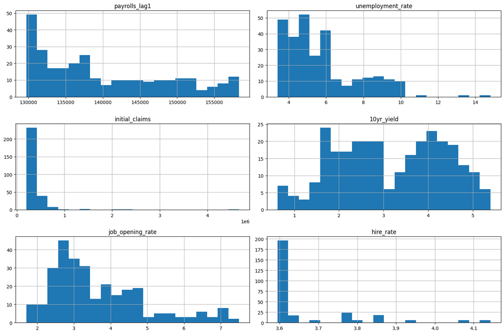

```python
features_l2 = [
    'payrolls_lag1',
    'unemployment_rate',
    'initial_claims',
    '10yr_yield',
    'job_opening_rate',
    'hire_rate'
]

print(master_df[features_l2].skew().sort_values(ascending=False))

master_df[features_l2].hist(bins=20, figsize=(15, 10))
plt.tight_layout()
plt.show()
```

```python
master_df['log_initial_claims'] = np.log(master_df['initial_claims'])
master_df['hire_rate_squared'] = master_df['hire_rate'] ** 2
master_df['unemployment_rate_log'] = np.log(master_df['unemployment_rate'])
```

```python
features_l2 = [
    'payrolls_lag1',
    'log_initial_claims',
    'hire_rate_squared',
    'unemployment_rate_log',
    '10yr_yield',
    'job_opening_rate'
]

X_l2 = master_df[features_l2]
y_l2 = master_df['payrolls']

split = int(len(master_df) * 0.8)
X_l2_train = X_l2.iloc[:split]
X_l2_test = X_l2.iloc[split:]
y_l2_train = y_l2.iloc[:split]
y_l2_test = y_l2.iloc[split:]
```

```python
model_expectation = Pipeline([
    ('scaler', StandardScaler()),
    ('regressor', RidgeCV(alphas=np.logspace(-3, 3, 25), cv=TimeSeriesSplit(n_splits=5)))
])
```

```python
model_expectation.fit(X_l2_train, y_l2_train)

y_l2_pred = model_expectation.predict(X_l2_test)

mae = mean_absolute_error(y_l2_test, y_l2_pred)
mse = mean_squared_error(y_l2_test, y_l2_pred)
r2 = r2_score(y_l2_test, y_l2_pred)
```

### Ridge Regression Results

The Ridge Regression expectations model achieved an out-of-sample $MAE$ of 4,124 payrolls and an out-of-sample $R^2$ of 0.46. While the model does not fully explain variation in payroll levels, it captures approximately 46% of the out-of-sample variation and successfully tracks the broader trajectory of payroll growth over time.

The Actual vs. Predicted Payrolls plot shows that the model generally follows the long-run trend in payrolls, indicating that the selected labor market and macroeconomic indicators contain meaningful information regarding future payroll developments. However, the predicted series consistently remains below the realized payroll levels throughout the test period, suggesting a systematic underestimation bias.

This conclusion is reinforced by the residual analysis. Residuals remain positive across the entire out-of-sample period and exhibit a mean and median residual of 4,124 and 3,505 respectively. Rather than fluctuating randomly around zero, the residuals display a persistent positive bias that gradually declines through time. This pattern indicates that the model does not fully capture the strong upward trend present in the payroll series and systematically predicts payroll levels below those ultimately realized.

The substantial gap between the in-sample and out-of-sample performance (Train R² = 0.99 versus Test R² = 0.46) further suggests that while the model fits historical payroll levels extremely well, its ability to generalize to future observations is more limited. This is not unexpected given the persistent nature of payrol levels and the relatively limited macroeconomic dataset we used to train the model.

```
MAE: 4123.986781920931
MSE: 21849714.33351094
R^2: 0.45702399273260175
```

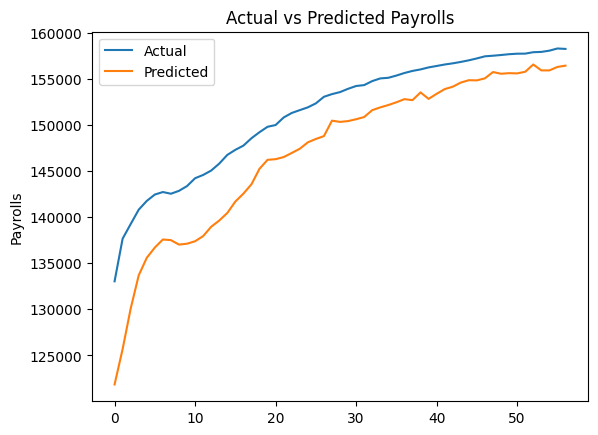

```python
print(f"MAE: {mae}")
print(f"MSE: {mse}")
print(f"R^2: {r2}")

plt.Figure(figsize=(10,5))

plt.plot(y_l2_test.values, label='Actual')
plt.plot(y_l2_pred, label='Predicted')
plt.title('Actual vs Predicted Payrolls')
plt.ylabel('Payrolls')
plt.legend()
plt.show()
```

```python
r2_train = model_expectation.score(X_l2_train, y_l2_train)
r2_test = model_expectation.score(X_l2_test, y_l2_test)
print(f"R^2 (Train): {r2_train}")
print(f"R^2 (Test): {r2_test}")
```

```
R^2 (Train): 0.9859337545853945
R^2 (Test): 0.45702399273260175
```

### Residual Analysis

The Ridge Regression expectations model exhibits a persistent positive residual throughout the test period, indicating that the model systematically underestimates payroll levels. The average residual is 4,124, while the median residual is 3,505. Furthermore, the residuals remain positive across nearly the entire out-of-sample period rather than fluctuating around zero.

This pattern suggests that the model does not fully capture the strong upward trend present in the payroll series. While the model is able to track the general direction of payroll growth, it consistently predicts levels below the realized values.

```
Mean residual: 4123.986781920931
Median residual: 3504.8674725616
```

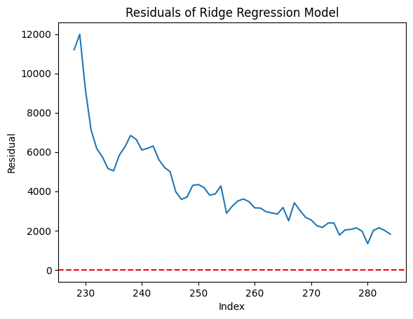

```python
residuals = y_l2_test - y_l2_pred
print('Mean residual:', np.mean(residuals))
print('Median residual:', np.median(residuals))

plt.plot(residuals)
plt.axhline(0, color='red', linestyle='--')
plt.title('Residuals of Ridge Regression Model')
plt.xlabel('Index')
plt.ylabel('Residual')
plt.show()
```

```python
master_df['predicted_payrolls'] = model_expectation.predict(X_l2)
master_df['predicted_payrolls_pct_change'] = master_df['predicted_payrolls'].pct_change()
```

### Constructing Payroll Surprise Variables

After generating payroll expectations using the Ridge Regression model, payroll surprise classifications were constructed using the distribution of the model-implied payroll growth rate. Observations were classified according to the upper and lower quartiles of predicted payroll growth. This approach focuses attention on periods of unusually strong or weak expected labor market performance while maintaining a balanced distribution of observations across classes.

The 25th percentile of predicted payroll growth is -0.0405%, while the 75th percentile is 0.2429%. Observations were classified as follows:

- **Upside Surprise (2):** Predicted payroll growth exceeded the 75th percentile.
- **No Surprise (1):** Predicted payroll growth fell between the 25th and 75th percentiles.
- **Downside Surprise (0):** Predicted payroll growth fell below the 25th percentile.

This methodology resulted in the following class distribution:

| Classification | Observations |
| --- | --- |
| Upside Surprise | 71 |
| No Surprise | 143 |
| Downside Surprise | 71 |

By defining surprises relative to the tails of the model-implied payroll growth distribution, the classification framework focuses on economically meaningful periods of unusually strong or weak labor market conditions.

These classifications serve as the target variables for the models developed in this project. Two approaches are considered:

1. **Multinomial Classification** – A single model is trained to classify observations into one of three categories: upside surprise, no surprise, or downside surprise.
2. **Binary Classification** – Separate models are trained to identify upside surprises and downside surprises independently. This approach allows each model to focus on a specific type of payroll surprise and capture potentially asymmetric relationships between economic indicators and labor market outcomes.

```python
master_df['predicted_payrolls_pct_change'].quantile([0.05, 0.10, 0.15, 0.20, 0.25, 0.30, 0.35, 0.40, 0.45, 0.50, 0.55, 0.60, 0.65, 0.70, 0.75, 0.80, 0.85, 0.90, 0.95])
```

```
0.05   -0.003765
0.10   -0.002515
0.15   -0.001581
0.20   -0.000849
0.25   -0.000405
0.30   -0.000090
0.35    0.000250
0.40    0.000510
0.45    0.000772
0.50    0.001140
0.55    0.001449
0.60    0.001685
0.65    0.001844
0.70    0.002141
0.75    0.002429
0.80    0.002957
0.85    0.003602
0.90    0.004676
0.95    0.006036
Name: predicted_payrolls_pct_change, dtype: float64
```

```python
lower = master_df['predicted_payrolls_pct_change'].quantile(0.25)
upper = master_df['predicted_payrolls_pct_change'].quantile(0.75)

master_df['upside_surprise'] = master_df['predicted_payrolls_pct_change'].apply(lambda x: 1 if x > upper else 0)
master_df['downside_surprise'] = master_df['predicted_payrolls_pct_change'].apply(lambda x: 1 if x < lower else 0)
master_df['surprise'] = master_df['predicted_payrolls_pct_change'].apply(lambda x: 2 if x > upper else (0 if x < lower else 1))
```

```python
print(master_df['upside_surprise'].value_counts())
print(master_df['downside_surprise'].value_counts())
print(master_df['surprise'].value_counts())

master_df.head()
```

```
upside_surprise
0    214
1     71
Name: count, dtype: int64
downside_surprise
0    214
1     71
Name: count, dtype: int64
surprise
1    143
0     71
2     71
Name: count, dtype: int64
```

|  | DATE | payrolls | unemployment_rate | initial_claims | cont_claims | 2yr_yield | 10yr_yield | 10yr_2yr_spread | sentiment | month | ... | discharge_momentum | payrolls_pct_change | log_initial_claims | hire_rate_squared | unemployment_rate_log | predicted_payrolls | predicted_payrolls_pct_change | upside_surprise | downside_surprise | surprise |
| --- | --- | --- | --- | --- | --- | --- | --- | --- | --- | --- | --- | --- | --- | --- | --- | --- | --- | --- | --- | --- | --- |
| 0 | 2001-04-30 | 132458.0 | 4.4 | 396750.0 | 2697250.0 | 4.234000 | 5.141000 | 0.907000 | 88.4 | 4 | ... | -0.016667 | -0.002207 | 12.891062 | 12.960000 | 1.481605 | 132108.393835 | NaN | 0 | 0 | 1 |
| 1 | 2001-05-31 | 132408.0 | 4.3 | 394500.0 | 2819250.0 | 4.260000 | 5.391364 | 1.131364 | 92.0 | 5 | ... | 0.011111 | -0.000377 | 12.885374 | 13.080278 | 1.458615 | 132089.839582 | -0.000140 | 0 | 0 | 1 |
| 2 | 2001-06-30 | 132300.0 | 4.5 | 397200.0 | 2947400.0 | 4.080000 | 5.284286 | 1.204286 | 92.6 | 6 | ... | -0.005556 | -0.000816 | 12.892195 | 12.920031 | 1.504077 | 131945.585776 | -0.001092 | 0 | 1 | 0 |
| 3 | 2001-07-31 | 132172.0 | 4.6 | 398000.0 | 3030750.0 | 4.038571 | 5.236190 | 1.197619 | 92.4 | 7 | ... | 0.005556 | -0.000967 | 12.894207 | 12.960000 | 1.526056 | 131669.874858 | -0.002090 | 0 | 1 | 0 |
| 4 | 2001-08-31 | 132021.0 | 4.9 | 398000.0 | 3120000.0 | 3.757391 | 4.971304 | 1.213913 | 91.5 | 8 | ... | 0.005556 | -0.001142 | 12.894207 | 13.000031 | 1.589235 | 131922.169459 | 0.001916 | 0 | 0 | 1 |

5 rows × 42 columns

```python
#master_df.to_csv('master_df.csv')
```

## **Modeling Binary Upside and Downside Surprises With XGBoost**

To identify periods associated with unusually strong and unusually weak labor market performance, separate XGBoost classifiers were developed for upside and downside payroll surprise regimes. Framing the problem as two binary classification tasks allows each model to focus exclusively on the economic conditions associated with its target outcome, providing a more targeted assessment of payroll surprise predictability.

```python
features = [
    'sentiment_lag1',
    'payrolls_lag1',
    'unemployment_rate_3mo_avg',
    'initial_claims_lag1',
    'initial_claims_momentum',
    'cont_claims_lag1',
    'cont_claims_momentum',
    '2yr_yield_volatility',
    '10yr_yield_volatility',
    'jor_3mo_avg',
    'jor_momentum',
    'hire_3mo_avg',
    'hire_momentum',
    'quit_3mo_avg',
    'quit_momentum',
    'discharge_3mo_avg',
    'discharge_momentum'
]
```

### Upside Surprise Model

```python
# Upside Surprise Sets

X_upside = master_df[features]
y_upside = master_df['upside_surprise']

X_train_upside, X_test_upside, y_train_upside, y_test_upside = train_test_split(X_upside, y_upside, random_state=42)
```

```python
# Initial XGBoost Model for Predicting Upside Surprises

upside_xgb = xgb.XGBClassifier(objective='binary:logistic',
                               eval_metric='auc',
                               seed=42)
upside_xgb.fit(X_train_upside,
               y_train_upside,
               verbose=False,
               eval_set=[(X_test_upside, y_test_upside)]
               )
```

```
XGBClassifier(base_score=None, booster=None, callbacks=None,
              colsample_bylevel=None, colsample_bynode=None,
              colsample_bytree=None, device=None, early_stopping_rounds=None,
              enable_categorical=False, eval_metric='auc', feature_types=None,
              feature_weights=None, gamma=None, grow_policy=None,
              importance_type=None, interaction_constraints=None,
              learning_rate=None, max_bin=None, max_cat_threshold=None,
              max_cat_to_onehot=None, max_delta_step=None, max_depth=None,
              max_leaves=None, min_child_weight=None, missing=nan,
              monotone_constraints=None, multi_strategy=None, n_estimators=None,
              n_jobs=None, num_parallel_tree=None, ...)
```

### XGBoost Upside Surprise Model Performance

The XGBoost classifier achieved an ROC-AUC score of 0.692, indicating modest discriminatory power in distinguishing upside surprises from non-upside surprises. Overall classification accuracy was 76%, though this figure is influenced by the larger number of non-upside observations in the test set.

The model correctly identified 4 of 18 upside surprises (recall = 0.22) and 51 of 54 non-upside surprises (recall = 0.94). Precision for the upside surprise class was 0.57, meaning that when the model predicted an upside surprise, it was correct approximately 57% of the time. While the model was highly effective at identifying periods without an upside surprise, it struggled to capture a meaningful share of actual upside surprise events.

The confusion matrix highlights this imbalance in performance. The model correctly classified 51 non-upside surprise observations and only 4 upside surprise observations, while failing to identify 14 of the 18 upside surprise events. This suggests that the classifier is heavily biased toward predicting the majority class and tends to issue upside surprise signals only when confidence is particularly high.

Although the ROC-AUC score indicates that the model contains some predictive signal, the low recall for upside surprises limits its practical usefulness as a forecasting tool. In its current form, the model is better suited for ruling out upside surprise regimes than for reliably identifying them in advance. Future improvements may require additional explanatory variables, a larger training sample, alternative threshold selection, or techniques designed to address class imbalance.

```
ROC AUC Score for Upside Surprise Model: 0.6924
Classification Report for Upside Surprises:
                     precision    recall  f1-score   support

No Upside Surprise       0.78      0.94      0.86        54
   Upside Surprise       0.57      0.22      0.32        18

          accuracy                           0.76        72
         macro avg       0.68      0.58      0.59        72
      weighted avg       0.73      0.76      0.72        72
```

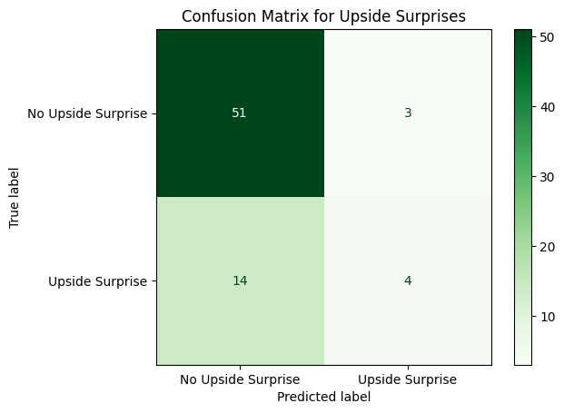

```python
upside_xgb_report = classification_report(y_test_upside, upside_xgb.predict(X_test_upside), target_names=['No Upside Surprise', 'Upside Surprise'])
upside_y_probs = upside_xgb.predict_proba(X_test_upside)[:, 1]

print(f"ROC AUC Score for Upside Surprise Model: {roc_auc_score(y_test_upside, upside_y_probs):.4f}")
print("Classification Report for Upside Surprises:\n", upside_xgb_report)

ConfusionMatrixDisplay.from_estimator(upside_xgb, X_test_upside, y_test_upside, display_labels=['No Upside Surprise', 'Upside Surprise'], cmap='Greens')
plt.title('Confusion Matrix for Upside Surprises')
plt.show()
```

### Optimized Upside Surprise Model

```python
# 'reg_lambda': [0, 0.1, 0.5, 1.0]

param_grid = {
    'max_depth': [1, 2, 3, 4, 5],
    'learning_rate': [0.01, 0.03, 0.05, 0.1],
    'n_estimators': [50, 100, 200, 300],
    'subsample': [0.5, 0.6, 0.8, 1.0],
    'colsample_bytree': [0.5, 0.6, 0.8, 1.0],
    'min_child_weight': [1, 2, 3, 5, 10],
    'gamma': [0, 0.1, 0.3, 0.5, 1.0],
    'reg_alpha': [0, 0.01, 0.1, 1.0, 10.0],
    'reg_lambda': [0.1, 1, 10, 100]
}

params = RandomizedSearchCV(
    estimator=upside_xgb,
    param_distributions=param_grid,
    n_iter=50,
    scoring='roc_auc',
    cv=TimeSeriesSplit(n_splits=5),
    random_state=42
)

params.fit(X_train_upside, y_train_upside)
print(params.best_params_)
print(params.best_score_)
```

```
{'subsample': 0.6, 'reg_lambda': 10, 'reg_alpha': 0, 'n_estimators': 300, 'min_child_weight': 1, 'max_depth': 3, 'learning_rate': 0.1, 'gamma': 0, 'colsample_bytree': 0.8}
0.679455317169603
```

```python
# Optimized XGBoost Model for Predicting Upside Surprises

opt_upside_xgb = xgb.XGBClassifier(
    objective='binary:logistic',
    eval_metric='auc',
    **params.best_params_,
    seed=42
)
opt_upside_xgb.fit(X_train_upside, y_train_upside,
                   verbose=False,
                   eval_set=[(X_test_upside, y_test_upside)]
                   )
```

```
XGBClassifier(base_score=None, booster=None, callbacks=None,
              colsample_bylevel=None, colsample_bynode=None,
              colsample_bytree=0.8, device=None, early_stopping_rounds=None,
              enable_categorical=False, eval_metric='auc', feature_types=None,
              feature_weights=None, gamma=0, grow_policy=None,
              importance_type=None, interaction_constraints=None,
              learning_rate=0.1, max_bin=None, max_cat_threshold=None,
              max_cat_to_onehot=None, max_delta_step=None, max_depth=3,
              max_leaves=None, min_child_weight=1, missing=nan,
              monotone_constraints=None, multi_strategy=None, n_estimators=300,
              n_jobs=None, num_parallel_tree=None, ...)
```

### Cross-Validated XGBoost Upside Model Performance

After tuning the model's hyperparameters using cross-validation, performance improved across nearly all evaluation metrics. The optimized XGBoost classifier achieved an ROC-AUC score of **0.768**, an increase from **0.692** in the baseline model, indicating a stronger ability to distinguish upside surprises from non-upside surprises.

Overall classification accuracy increased from 76% to 82%, while precision for the upside surprise class improved from 0.57 to 0.73. Recall for upside surprises also increased substantially from 0.22 to 0.44, meaning the optimized model correctly identified 8 of 18 upside surprises, compared to only 4 of 18 under the baseline specification.

The confusion matrix highlights where these gains originated. The optimized model continued to perform strongly on the non-upside class, correctly classifying 51 of 54 non-upside observations (recall = 0.94), while doubling the number of correctly identified upside surprises from 4 to 8. At the same time, false positives remained unchanged at only 3 observations, indicating that the improvement in upside surprise detection was achieved without sacrificing performance on the majority class.

Compared to the baseline model, the optimized specification exhibits a more balanced performance profile. The increase in ROC-AUC, accuracy, precision, recall, and F1-score for the upside surprise class suggests that hyperparameter tuning successfully improved the model's ability to identify economically meaningful upside surprises while maintaining a low false-positive rate.

Despite these improvements, forecasting upside payroll surprises remains a challenging task. The model still failed to identify 10 of the 18 upside surprise events in the test sample, indicating that a substantial portion of upside surprises remain difficult to predict using the available labor market and macroeconomic indicators. Nevertheless, the cross-validated model represents a meaningful improvement over the baseline specification and provides evidence that the selected predictors contain useful information regarding future upside payroll surprise regimes.

```
ROC AUC Score for Optimized Upside Surprise Model: 0.7675
Classification Report for Optimized Upside Surprises:
                     precision    recall  f1-score   support

No Upside Surprise       0.84      0.94      0.89        54
   Upside Surprise       0.73      0.44      0.55        18

          accuracy                           0.82        72
         macro avg       0.78      0.69      0.72        72
      weighted avg       0.81      0.82      0.80        72
```

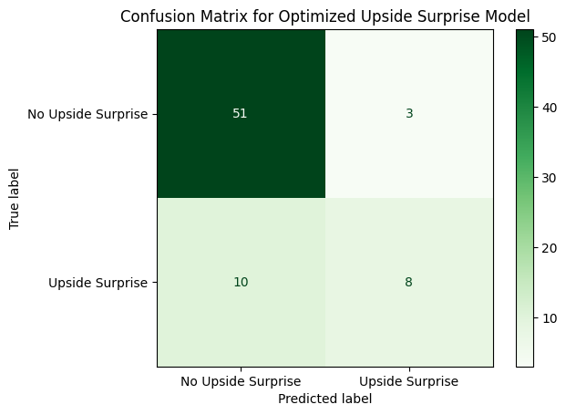

```python
opt_upside_xgb_report = classification_report(y_test_upside, opt_upside_xgb.predict(X_test_upside), target_names=['No Upside Surprise', 'Upside Surprise'])
opt_upside_y_probs = opt_upside_xgb.predict_proba(X_test_upside)[:, 1]

print(f"ROC AUC Score for Optimized Upside Surprise Model: {roc_auc_score(y_test_upside, opt_upside_y_probs):.4f}")
print("Classification Report for Optimized Upside Surprises:\n", opt_upside_xgb_report)

ConfusionMatrixDisplay.from_estimator(opt_upside_xgb, X_test_upside, y_test_upside, display_labels=['No Upside Surprise', 'Upside Surprise'], cmap='Greens')
plt.title('Confusion Matrix for Optimized Upside Surprise Model')
plt.show()
```

### Upside ROC Curve Analysis

The cross-validated XGBoost model achieved an out-of-sample ROC-AUC score of 0.768, representing a meaningful improvement over the baseline model's ROC-AUC of 0.692. The ROC curve for the optimized model lies above the baseline curve across most classification thresholds, indicating a stronger ability to distinguish upside surprise regimes from non-upside surprise regimes.

The improvement in ROC-AUC is consistent with the gains observed in the classification metrics. While the baseline model correctly identified only 4 of 18 upside surprise events, the optimized model increased this figure to 8 of 18 while maintaining the same number of false positives. The ROC curve confirms that these improvements are not simply the result of a favorable classification threshold, but instead reflect a genuine increase in the model's ability to rank observations according to their likelihood of producing an upside payroll surprise.

Although the optimized model remains far from perfect, the results suggest that publicly available labor market and macroeconomic indicators contain meaningful information regarding future upside payroll surprise regimes. Given the inherent difficulty of forecasting labor market surprises and the relatively limited sample size available for training, an ROC-AUC approaching 0.80 provides encouraging evidence that the model is capturing economically relevant patterns in the data.

Overall, the ROC analysis supports the conclusion that cross-validation materially improved model performance and strengthened the model's ability to identify conditions associated with stronger-than-expected payroll growth.

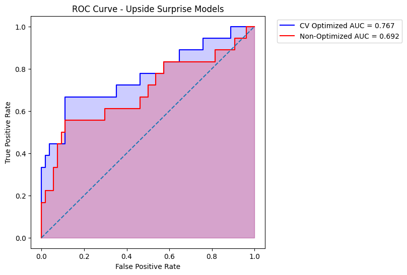

```python
fpr, tpr, thresholds = roc_curve(
    y_test_upside,
    upside_y_probs
)

fpr_opt, tpr_opt, thresholds_opt = roc_curve(
    y_test_upside,
    opt_upside_y_probs
)

plt.figure(figsize=(6,6))
plt.plot(fpr_opt, tpr_opt, label=f"Optimized AUC = {roc_auc_score(y_test_upside, opt_upside_y_probs):.3f}", color='blue')
plt.plot(fpr, tpr, label=f"AUC = {roc_auc_score(y_test_upside, upside_y_probs):.3f}", color='red')
plt.plot([0,1], [0,1], linestyle="--")
plt.fill_between(fpr_opt, tpr_opt, alpha=0.2, color='blue')
plt.fill_between(fpr, tpr, alpha=0.2, color='red')
plt.xlabel("False Positive Rate")
plt.ylabel("True Positive Rate")
plt.title("ROC Curve - Upside Surprise Models")
plt.legend(
    loc='upper right',
    labels=[
        f"CV Optimized AUC = {roc_auc_score(y_test_upside, opt_upside_y_probs):.3f}",
        f"Non-Optimized AUC = {roc_auc_score(y_test_upside, upside_y_probs):.3f}"
    ],
    bbox_to_anchor=(1.6, 1)
)
plt.show()
```

### Downside Surprise Model

```python
X_downside = master_df[features]
y_downside = master_df['downside_surprise']

X_train_downside, X_test_downside, y_train_downside, y_test_downside = train_test_split(X_downside, y_downside, random_state=42)
```

```python
downside_xgb = xgb.XGBClassifier(objective='binary:logistic',
                                 eval_metric='auc',
                                 seed=42)
downside_xgb.fit(X_train_downside,
                y_train_downside,
                verbose=False,
                eval_set=[(X_test_downside, y_test_downside)]
                )
```

```
XGBClassifier(base_score=None, booster=None, callbacks=None,
              colsample_bylevel=None, colsample_bynode=None,
              colsample_bytree=None, device=None, early_stopping_rounds=None,
              enable_categorical=False, eval_metric='auc', feature_types=None,
              feature_weights=None, gamma=None, grow_policy=None,
              importance_type=None, interaction_constraints=None,
              learning_rate=None, max_bin=None, max_cat_threshold=None,
              max_cat_to_onehot=None, max_delta_step=None, max_depth=None,
              max_leaves=None, min_child_weight=None, missing=nan,
              monotone_constraints=None, multi_strategy=None, n_estimators=None,
              n_jobs=None, num_parallel_tree=None, ...)
```

### Downside Surprise Model Performance

The XGBoost classifier achieved an ROC-AUC score of 0.740, indicating a moderate ability to distinguish downside surprise regimes from non-downside surprise regimes. Overall classification accuracy was 79%, suggesting that the model captures meaningful information regarding the economic conditions associated with weaker-than-expected payroll growth.

The model correctly identified 6 of 19 downside surprises (recall = 0.32) and 51 of 53 non-downside surprise observations (recall = 0.96). Precision for the downside surprise class was 0.75, meaning that when the model predicted a downside surprise, it was correct approximately three-quarters of the time. This indicates that downside surprise predictions were generally reliable, although many downside surprise events remained undetected.

The confusion matrix highlights the model's strengths and limitations. Of the 19 actual downside surprise observations, 13 were incorrectly classified as non-downside surprises, while 6 were correctly identified. At the same time, the model generated only 2 false positive downside surprise signals, demonstrating a relatively conservative prediction strategy. This conservatism contributed to the model's high precision but limited its ability to capture a larger share of downside surprise events.

Overall, the model contains useful predictive signal regarding downside surprise regimes, as evidenced by its ROC-AUC score of 0.740. However, the low recall rate suggests that the model struggles to identify a majority of downside surprise events, limiting its effectiveness as a standalone forecasting tool.

```
ROC AUC Score for Downside Surprise Model: 0.7398
Classification Report for Downside Surprises:
                       precision    recall  f1-score   support

No Downside Surprise       0.80      0.96      0.87        53
   Downside Surprise       0.75      0.32      0.44        19

            accuracy                           0.79        72
           macro avg       0.77      0.64      0.66        72
        weighted avg       0.78      0.79      0.76        72
```

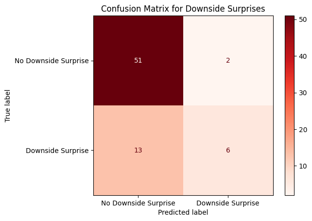

```python
downside_xgb_report = classification_report(y_test_downside, downside_xgb.predict(X_test_downside), target_names=['No Downside Surprise', 'Downside Surprise'])
downside_y_probs = downside_xgb.predict_proba(X_test_downside)[:, 1]

print(f"ROC AUC Score for Downside Surprise Model: {roc_auc_score(y_test_downside, downside_y_probs):.4f}")
print("Classification Report for Downside Surprises:\n", downside_xgb_report)

ConfusionMatrixDisplay.from_estimator(downside_xgb, X_test_downside, y_test_downside, display_labels=['No Downside Surprise', 'Downside Surprise'], cmap='Reds')
plt.title('Confusion Matrix for Downside Surprises')
plt.show()
```

### Optimized Downside Model

```python
params = RandomizedSearchCV(
    estimator=downside_xgb,
    param_distributions=param_grid,
    n_iter=50,
    scoring='roc_auc',
    cv=TimeSeriesSplit(n_splits=5),
    random_state=42
)

params.fit(X_train_downside, y_train_downside)
print(params.best_params_)
print(params.best_score_)
```

```
{'subsample': 0.6, 'reg_lambda': 10, 'reg_alpha': 0, 'n_estimators': 300, 'min_child_weight': 1, 'max_depth': 3, 'learning_rate': 0.1, 'gamma': 0, 'colsample_bytree': 0.8}
0.6448339260083102
```

```python
opt_downside_xgb = xgb.XGBClassifier(
    objective='binary:logistic',
    eval_metric='auc',
    **params.best_params_,
    seed=42
)
opt_downside_xgb.fit(X_train_downside, y_train_downside, verbose=False, eval_set=[(X_test_downside, y_test_downside)])
```

```
XGBClassifier(base_score=None, booster=None, callbacks=None,
              colsample_bylevel=None, colsample_bynode=None,
              colsample_bytree=0.8, device=None, early_stopping_rounds=None,
              enable_categorical=False, eval_metric='auc', feature_types=None,
              feature_weights=None, gamma=0, grow_policy=None,
              importance_type=None, interaction_constraints=None,
              learning_rate=0.1, max_bin=None, max_cat_threshold=None,
              max_cat_to_onehot=None, max_delta_step=None, max_depth=3,
              max_leaves=None, min_child_weight=1, missing=nan,
              monotone_constraints=None, multi_strategy=None, n_estimators=300,
              n_jobs=None, num_parallel_tree=None, ...)
```

### Cross-Validated Downside Surprise Model Performance

After tuning the model's hyperparameters using cross-validation, the downside surprise model exhibited improvements across nearly all evaluation metrics. The optimized XGBoost classifier achieved an ROC-AUC score of 0.751, a modest increase from 0.740 in the baseline model, indicating a slightly stronger ability to distinguish downside surprise regimes from non-downside surprise regimes.

Overall classification accuracy increased from 79% to 86%, while recall for downside surprises improved from 0.32 to 0.47. The optimized model correctly identified 9 of 19 downside surprise events, compared to 6 of 19 under the baseline model. This represents a meaningful improvement in downside surprise detection and suggests that hyperparameter optimization helped the model capture additional predictive information contained within the labor market and macroeconomic indicators.

One of the most notable characteristics of the optimized model is its exceptionally high precision. The model produced zero false positives, correctly classifying all 53 non-downside surprise observations in the test sample. As a result, downside surprise precision reached 1.00, meaning that every downside surprise prediction generated by the model was correct.

The confusion matrix illustrates the tradeoff clearly. While the model correctly identified 9 downside surprise events, it still failed to detect 10 of the 19 downside surprises in the test set. Consequently, despite perfect precision and improved recall, the model continues to miss a substantial proportion of downside surprise observations.

Overall, the results suggest that the optimized model contains meaningful predictive information regarding downside payroll surprise regimes. However, the recall rate of 0.47 indicates that forecasting downside surprises remains a difficult task, with more than half of downside surprise events still going undetected. While the model is highly reliable when it generates a downside signal, additional predictors or alternative modeling approaches may be necessary to achieve stronger downside-event detection.

```
ROC AUC Score for Optimized Downside Surprise Model: 0.7507
Classification Report for Optimized Downside Surprises:
                       precision    recall  f1-score   support

No Downside Surprise       0.84      1.00      0.91        53
   Downside Surprise       1.00      0.47      0.64        19

            accuracy                           0.86        72
           macro avg       0.92      0.74      0.78        72
        weighted avg       0.88      0.86      0.84        72
```

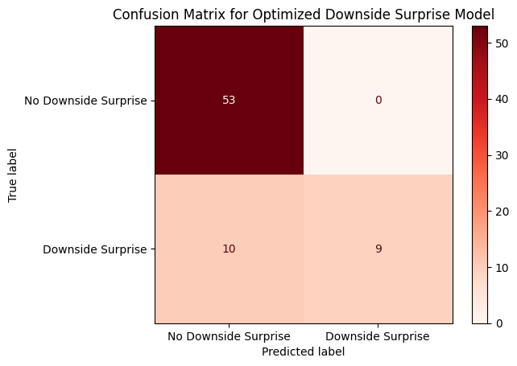

```python
opt_downside_xgb_report = classification_report(y_test_downside, opt_downside_xgb.predict(X_test_downside), target_names=['No Downside Surprise', 'Downside Surprise'])
opt_downside_y_probs = opt_downside_xgb.predict_proba(X_test_downside)[:, 1]

print(f"ROC AUC Score for Optimized Downside Surprise Model: {roc_auc_score(y_test_downside, opt_downside_y_probs):.4f}")
print("Classification Report for Optimized Downside Surprises:\n", opt_downside_xgb_report)

ConfusionMatrixDisplay.from_estimator(opt_downside_xgb, X_test_downside, y_test_downside, display_labels=['No Downside Surprise', 'Downside Surprise'], cmap='Reds')
plt.title('Confusion Matrix for Optimized Downside Surprise Model')
plt.show()
```

### Downside ROC Curve Analysis

The optimized model increased downside surprise recall from 0.32 to 0.47, correctly identifying 9 of 19 downside surprise events compared to 6 of 19 in the baseline specification. At the same time, the model eliminated false positives entirely, correctly classifying all 53 non-downside surprise observations. The ROC curve confirms that these gains reflect a genuine improvement in the model's ranking ability rather than simply a change in the classification threshold.

Despite these improvements, the ROC curves for both models remain relatively close together and only moderately separated from the 45-degree no-skill benchmark. This suggests that downside payroll surprises remain inherently difficult to forecast using the available labor market and macroeconomic indicators. Even the optimized model continues to miss more than half of the downside surprise events in the test sample.

Overall, the ROC analysis supports the conclusion that cross-validation and hyperparameter tuning improved the model's ability to rank downside surprise risk. While the predictive signal remains moderate, the results indicate that the model contains economically meaningful information and may be useful as a probabilistic risk assessment tool, particularly when combined with other forecasting approaches.

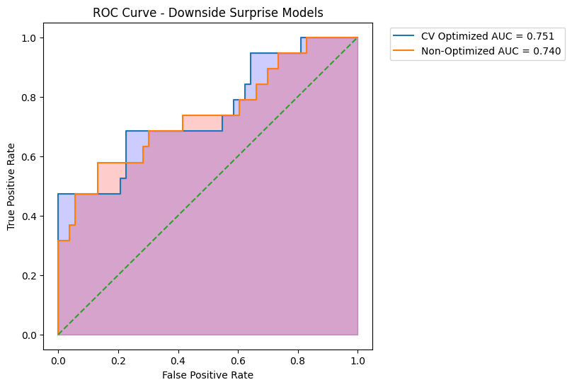

```python
fpr, tpr, thresholds = roc_curve(
    y_test_downside,
    downside_y_probs
)

opt_fpr, opt_tpr, opt_thresholds = roc_curve(
    y_test_downside,
    opt_downside_y_probs
)

plt.figure(figsize=(6,6))
plt.plot(opt_fpr, opt_tpr, label=f"CV Optimized AUC = {roc_auc_score(y_test_downside, opt_downside_y_probs):.3f}")
plt.plot(fpr, tpr, label=f"Non-Optimized AUC = {roc_auc_score(y_test_downside, downside_y_probs):.3f}")
plt.fill_between(opt_fpr, opt_tpr, alpha=0.2, color='blue')
plt.fill_between(fpr, tpr, alpha=0.2, color='red')
plt.plot([0,1], [0,1], linestyle="--")
plt.xlabel("False Positive Rate")
plt.ylabel("True Positive Rate")
plt.title("ROC Curve - Downside Surprise Models")
plt.legend(
    loc='upper right',
    labels=[
        f"CV Optimized AUC = {roc_auc_score(y_test_downside, opt_downside_y_probs):.3f}",
        f"Non-Optimized AUC = {roc_auc_score(y_test_downside, downside_y_probs):.3f}"
    ],
    bbox_to_anchor=(1.6, 1)
)
plt.show()
```

## **Modeling Surprises with Multinomial Classification**

```python
X = master_df[features]
y = master_df['surprise']

X_train, X_test, y_train, y_test = train_test_split(X, y, random_state=42)
```

```python
xgb_multi = xgb.XGBClassifier(objective='multiclass',
                               eval_metric='auc',
                               seed=42)
xgb_multi.fit(X_train,
               y_train,
               verbose=False,
               eval_set=[(X_test, y_test)]
               )
```

```
XGBClassifier(base_score=None, booster=None, callbacks=None,
              colsample_bylevel=None, colsample_bynode=None,
              colsample_bytree=None, device=None, early_stopping_rounds=None,
              enable_categorical=False, eval_metric='auc', feature_types=None,
              feature_weights=None, gamma=None, grow_policy=None,
              importance_type=None, interaction_constraints=None,
              learning_rate=None, max_bin=None, max_cat_threshold=None,
              max_cat_to_onehot=None, max_delta_step=None, max_depth=None,
              max_leaves=None, min_child_weight=None, missing=nan,
              monotone_constraints=None, multi_strategy=None, n_estimators=None,
              n_jobs=None, num_parallel_tree=None, ...)
```

### Multinomial XGBoost Model Performance

The multinomial XGBoost classifier achieved an ROC-AUC score of 0.698, indicating a moderate ability to distinguish between downside surprise, no surprise, and upside surprise regimes. Overall classification accuracy was 57%, meaning the model correctly classified 41 of the 72 observations in the test sample.

Performance varied across the three classes. The model was most effective at identifying No Surprise observations, achieving a recall of 0.69 and correctly classifying 24 of 35 neutral observations. Performance was weaker for the two surprise classes. The model correctly identified 9 of 19 downside surprises (recall = 0.47) and 8 of 18 upside surprises (recall = 0.44), indicating that more than half of the surprise events in both directions remained undetected.

The confusion matrix provides additional insight into the model's classification behavior. A notable source of error was the tendency to classify surprise events as neutral observations. Of the 19 downside surprises, 9 were classified as No Surprise, while 10 of the 18 upside surprises were also classified as No Surprise. This suggests that the model may be better at identifying the direction of labor market conditions once a surprise regime is detected than it is at determining whether a surprise regime exists in the first place.

Despite these limitations, the model demonstrated relatively balanced performance across the three classes. Precision ranged from 0.47 for upside surprises to 0.75 for downside surprises, while recall ranged from 0.44 to 0.69. Unlike the binary models, which focused on a single outcome, the multinomial classifier was required to simultaneously distinguish among three possible labor market regimes, making the classification task considerably more difficult.

Overall, the multinomial model contains meaningful predictive signal, as evidenced by its ROC-AUC score approaching 0.70. However, the results also indicate that separating surprise regimes from normal labor market conditions remains challenging. The model's tendency to classify many surprise observations as neutral suggests that payroll surprise events may share characteristics with normal labor market environments, making precise regime identification difficult using the available set of economic indicators.

```
ROC AUC Score for Multinomial Surprise Model: 0.6982
Classification Report for Upside Surprises:
                    precision    recall  f1-score   support

Downside Surprise       0.75      0.47      0.58        19
      No Surprise       0.56      0.69      0.62        35
  Upside Surprise       0.47      0.44      0.46        18

         accuracy                           0.57        72
        macro avg       0.59      0.53      0.55        72
     weighted avg       0.59      0.57      0.57        72
```

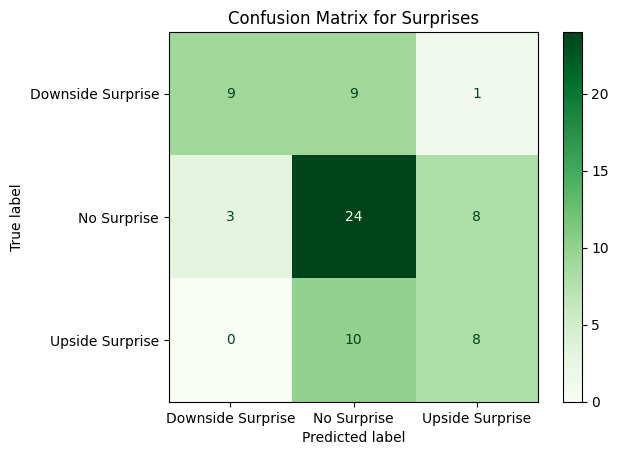

```python
xgb_report = classification_report(y_test, xgb_multi.predict(X_test), target_names=['Downside Surprise', 'No Surprise', 'Upside Surprise'])
y_probs = xgb_multi.predict_proba(X_test)

print(f"ROC AUC Score for Multinomial Surprise Model: {roc_auc_score(y_test, y_probs, multi_class='ovr'):.4f}")
print("Classification Report for Upside Surprises:\n", xgb_report)

ConfusionMatrixDisplay.from_estimator(xgb_multi, X_test, y_test, display_labels=['Downside Surprise', 'No Surprise', 'Upside Surprise'], cmap='Greens')
plt.title('Confusion Matrix for Surprises')
plt.show()
```

### Optimized Multinomial Classification

```python
param_grid = {
    'max_depth': [1, 2, 3, 4, 5],
    'learning_rate': [0.01, 0.03, 0.05, 0.1],
    'n_estimators': [50, 100, 200, 300],
    'subsample': [0.5, 0.6, 0.8, 1.0],
    'colsample_bytree': [0.5, 0.6, 0.8, 1.0],
    'min_child_weight': [1, 2, 3, 5, 10],
    'gamma': [0, 0.1, 0.3, 0.5, 1.0],
    'reg_alpha': [0, 0.01, 0.1, 1.0, 10.0],
    'reg_lambda': [0.1, 1, 10, 100]
}

params = RandomizedSearchCV(
    estimator=xgb.XGBClassifier(objective='multiclass', eval_metric='auc', seed=42),
    param_distributions=param_grid,
    n_iter=50,
    scoring='roc_auc',
    cv=TimeSeriesSplit(n_splits=5),
    random_state=42
)

params.fit(X_train, y_train)
print(params.best_params_)
print(params.best_score_)
```

```
{'subsample': 0.8, 'reg_lambda': 1, 'reg_alpha': 0.1, 'n_estimators': 50, 'min_child_weight': 2, 'max_depth': 2, 'learning_rate': 0.1, 'gamma': 0.5, 'colsample_bytree': 0.5}
nan
```

```python
opt_xgb = xgb.XGBClassifier(
    objective='multiclass',
    eval_metric='auc',
    **params.best_params_,
    seed=42
)
opt_xgb.fit(X_train, y_train,
                   verbose=False,
                   eval_set=[(X_test, y_test)]
                   )
```

```
XGBClassifier(base_score=None, booster=None, callbacks=None,
              colsample_bylevel=None, colsample_bynode=None,
              colsample_bytree=0.5, device=None, early_stopping_rounds=None,
              enable_categorical=False, eval_metric='auc', feature_types=None,
              feature_weights=None, gamma=0.5, grow_policy=None,
              importance_type=None, interaction_constraints=None,
              learning_rate=0.1, max_bin=None, max_cat_threshold=None,
              max_cat_to_onehot=None, max_delta_step=None, max_depth=2,
              max_leaves=None, min_child_weight=2, missing=nan,
              monotone_constraints=None, multi_strategy=None, n_estimators=50,
              n_jobs=None, num_parallel_tree=None, ...)
```

### Cross-Validated Multinomial XGBoost Model Performance

After tuning the model's hyperparameters using cross-validation, the multinomial XGBoost classifier achieved an ROC-AUC score of 0.747, representing a meaningful improvement over the baseline model's ROC-AUC of 0.698. Overall classification accuracy also improved from 57% to 62%, indicating that the optimized model was better able to distinguish among downside surprise, no surprise, and upside surprise regimes.

The largest improvement occurred in the No Surprise class. The optimized model correctly classified 33 of 35 neutral observations, increasing recall from 0.69 to 0.94. This suggests that hyperparameter optimization substantially improved the model's ability to identify periods of normal labor market conditions and reduced the tendency to incorrectly classify neutral observations as surprise events.

Performance for the surprise classes was more mixed. Precision for downside surprises improved from 0.75 to 1.00, meaning every downside surprise prediction generated by the model was correct. However, downside surprise recall declined from 0.47 to 0.37, with the model correctly identifying 7 of 19 downside surprise observations compared to 9 of 19 in the baseline model. Similarly, upside surprise precision increased from 0.47 to 0.62, but recall declined from 0.44 to 0.28, with the model correctly identifying only 5 of 18 upside surprise observations.

The confusion matrix highlights a notable shift in the model's behavior. Compared to the baseline, the optimized model became substantially more conservative when predicting surprise regimes. Rather than incorrectly assigning observations to the wrong surprise category, the model increasingly classified both upside and downside surprises as No Surprise. For example, 11 of 19 downside surprises and 13 of 18 upside surprises were classified as neutral observations. This behavior reduced false positives and improved precision, but came at the cost of missing a larger proportion of actual surprise events.

Overall, the optimized multinomial model demonstrates stronger overall discrimination and higher classification accuracy than the baseline specification. However, these gains were driven primarily by improved identification of neutral labor market conditions rather than enhanced detection of surprise regimes. The results illustrate a common tradeoff in classification problems: hyperparameter optimization produced a more conservative model with higher precision and lower false-positive rates, but reduced its willingness to classify observations as upside or downside surprises.

Consequently, while the optimized model provides a more accurate overall classification framework, the baseline multinomial model was somewhat more effective at identifying surprise events themselves.

```
ROC AUC Score for Optimized Multinomial Surprise Model: 0.7472
Classification Report for Upside Surprises:
                    precision    recall  f1-score   support

Downside Surprise       1.00      0.37      0.54        19
      No Surprise       0.58      0.94      0.72        35
  Upside Surprise       0.62      0.28      0.38        18

         accuracy                           0.62        72
        macro avg       0.73      0.53      0.55        72
     weighted avg       0.70      0.62      0.59        72
```

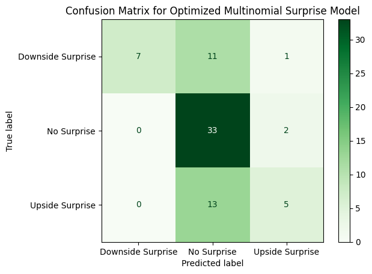

```python
opt_xgb_report = classification_report(y_test, opt_xgb.predict(X_test), target_names=['Downside Surprise', 'No Surprise', 'Upside Surprise'])
y_probs_opt = opt_xgb.predict_proba(X_test)

print(f"ROC AUC Score for Optimized Multinomial Surprise Model: {roc_auc_score(y_test, y_probs_opt, multi_class='ovr'):.4f}")
print("Classification Report for Upside Surprises:\n", opt_xgb_report)

ConfusionMatrixDisplay.from_estimator(opt_xgb, X_test, y_test, display_labels=['Downside Surprise', 'No Surprise', 'Upside Surprise'], cmap='Greens')
plt.title('Confusion Matrix for Optimized Multinomial Surprise Model')
plt.show()
```

### Multinomial ROC Curve Analysis

Because ROC curves are inherently binary classification metrics, the multinomial model was evaluated using a one-vs-rest approach. Under this framework, a separate ROC curve is constructed for each class by treating the target class as the positive outcome and combining the remaining two classes into a single negative group. Consequently, each ROC-AUC score measures the model's ability to distinguish one labor market regime from all other regimes combined.

The model achieved class-specific ROC-AUC scores of 0.803 for downside surprises, 0.681 for no-surprise observations, and 0.757 for upside surprises.

The strongest performance was observed in the Downside Surprise class, with an ROC-AUC of 0.803. In practical terms, this means that when comparing a randomly selected downside surprise observation with a randomly selected observation from either the no-surprise or upside-surprise classes, the model assigns a higher downside-surprise probability approximately 80% of the time. This suggests that the model is identifying patterns that are often present before downside payroll surprises occur.

Performance was weakest for the No Surprise class, which achieved an ROC-AUC of 0.681. This implies that neutral labor market conditions are more difficult to separate from surprise regimes than downside and upside surprises are from the remainder of the sample. Given that no-surprise observations lie between upside and downside outcomes by construction, some overlap between classes is expected.

Importantly, the one-vs-rest ROC curves evaluate the model's ability to rank observations according to class-specific probabilities rather than its ability to assign the correct final class label. As a result, the ROC-AUC values are notably stronger than the corresponding classification metrics. While the confusion matrix shows that many surprise observations were ultimately classified as No Surprise, the ROC analysis indicates that the model frequently recognized the presence of surprise-related characteristics even when the final class prediction was incorrect.

Overall, the one-vs-rest ROC analysis suggests that the multinomial model contains meaningful predictive signal for both downside and upside payroll surprise regimes. The results indicate that the model is more effective at ranking observations by surprise risk than at making precise three-way classifications.

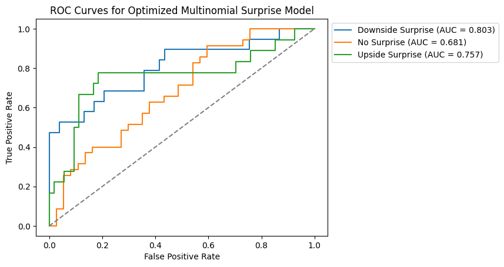

```python
# One-vs-Rest ROC Curves for Multinomial Model

from sklearn.preprocessing import label_binarize

y_test_binarized = label_binarize(y_test, classes=[0, 1, 2])
y_probs_opt = opt_xgb.predict_proba(X_test)

for i, label in enumerate(['Downside Surprise', 'No Surprise', 'Upside Surprise']):
    fpr, tpr, thresholds = roc_curve(
        y_test_binarized[:, i], y_probs_opt[:, i]
        )
    plt.plot(
        fpr, tpr, label=f"{label} (AUC = {roc_auc_score(y_test_binarized[:, i],
        y_probs_opt[:, i]):.3f})")

plt.title("ROC Curves for Optimized Multinomial Surprise Model")
plt.xlabel("False Positive Rate")
plt.ylabel("True Positive Rate")
plt.plot([0, 1], [0, 1], linestyle="--", color='gray')
plt.legend(loc='upper right',
    labels=[
         f"Downside Surprise (AUC = {roc_auc_score(y_test_binarized[:, 0], y_probs_opt[:, 0]):.3f})",
        f"No Surprise (AUC = {roc_auc_score(y_test_binarized[:, 1], y_probs_opt[:, 1]):.3f})",
        f"Upside Surprise (AUC = {roc_auc_score(y_test_binarized[:, 2], y_probs_opt[:, 2]):.3f})"
        ],
        bbox_to_anchor=(1.6, 1)
)
plt.show()
```

## Conclusion

This project developed a statistical learning framework for identifying potential payroll surprises using publicly available labor market and financial market data. By combining economic indicators from FRED and BLS, constructing a proxy expectations model, engineering labor market features, and applying both binary and multinomial XGBoost classifiers, the analysis explored whether meaningful labor market surprises can be anticipated before the release of the Employment Situation Report.

Overall, the results suggest that labor market conditions do contain predictive information related to future payroll surprises. Model performance improved following feature engineering and hyperparameter optimization, particularly within the binary classification framework, indicating that nonlinear relationships between economic indicators and payroll outcomes can be partially captured using machine learning techniques.

At the same time, the analysis highlights the inherent difficulty of forecasting macroeconomic surprises. While the models demonstrated useful predictive ability, performance remained far from perfect and many surprise events remained difficult to identify consistently. This reflects both the complexity of labor market dynamics and the challenge of approximating market expectations using publicly available data.

Several limitations should be acknowledged. The analysis relies on a model-based proxy for consensus expectations rather than proprietary economist forecasts, the sample size is relatively limited for a machine learning application, and the available predictors may not fully capture all factors influencing payroll outcomes. Future work could incorporate additional labor market indicators, alternative surprise definitions, and higher-frequency financial market data to further improve predictive performance.

Despite these limitations, the project demonstrates the practical application of econometrics, feature engineering, time-series modeling, and machine learning to a real-world financial forecasting problem. More importantly, it illustrates that labor market surprises are not entirely random and that publicly available economic data can provide valuable information about conditions associated with unusually strong or weak payroll outcomes.